# RNA-Seq Data Analysis

## System role

Act as an experienced bioinformatician. Write R code, without explanation, to analyze RNA-Seq read counts data

## Task 1

Read raw counts data from a file called ’../GSE37704_sailfish.csv’. Treat the first column as row id. Each row represents a gene. Print the number of genes and the first 10 rows.

```r
# Load libraries
library(readr)

# Read raw counts data
raw_counts <- read.csv("../GSE37704_sailfish.csv", row.names = 1)

# Print the number of genes
cat("Number of genes:", nrow(raw_counts), "\n")
```

```
## Number of genes: 19808
```

```r
# Print the first 10 rows
head(raw_counts, 10)
```

```
##                 control_1 control_2 control_3 Hoxa1KN_1 Hoxa1KN_2 Hoxa1KN_3
## ENSG00000198888     17528     23007     30241     24418     29152     34416
## ENSG00000198763     21264     26720     35550     28878     32416     38422
## ENSG00000198804    130975    151207    195514    178130    196727    244670
## ENSG00000198712     49769     61906     78608     66478     69758     86808
## ENSG00000228253      9304     11160     12830     12608     13041     16063
## ENSG00000198899     45401     51260     66851     63433     66123     79215
## ENSG00000198938     48934     60098     73735     68369     75057     91468
## ENSG00000198840      4228      5158      6058      5932      6446      7760
## ENSG00000212907     10184     10959     14985     13072     14015     16715
## ENSG00000198886     77648     84582    113525    105426    110399    136075
```

## Task 2

The row names are Ensembl gene IDs. Using the org.Hs.eg.db package, retrieve corresponding gene symbols, Entrez gene IDs, and gene names. Save the information in a CSV file. Print the first 5 rows.

```r
# Load libraries
library(org.Hs.eg.db)

# Retrieve corresponding gene symbols, Entrez gene IDs, and gene names
ensembl_ids <- rownames(raw_counts)
gene_symbols <- mapIds(org.Hs.eg.db, keys = ensembl_ids, column = "SYMBOL", keytype = "ENSEMBL")
entrez_ids <- mapIds(org.Hs.eg.db, keys = ensembl_ids, column = "ENTREZID", keytype = "ENSEMBL")
gene_names <- mapIds(org.Hs.eg.db, keys = ensembl_ids, column = "GENENAME", keytype = "ENSEMBL")

# Save the information in a data frame
annotation_df <- data.frame(GeneID = ensembl_ids, Symbol = gene_symbols, EntrezID = entrez_ids, GeneName = gene_names)

# Save the data frame to a CSV file
write.csv(annotation_df, "gene_annotation.csv", row.names = FALSE)

# Print the first 5 rows
head(annotation_df, 5)
```

```
##                          GeneID Symbol EntrezID                        GeneName
## ENSG00000198888 ENSG00000198888    ND1     4535    NADH dehydrogenase subunit 1
## ENSG00000198763 ENSG00000198763    ND2     4536    NADH dehydrogenase subunit 2
## ENSG00000198804 ENSG00000198804   COX1     4512  cytochrome c oxidase subunit I
## ENSG00000198712 ENSG00000198712   COX2     4513 cytochrome c oxidase subunit II
## ENSG00000228253 ENSG00000228253   ATP8     4509       ATP synthase F0 subunit 8
```

## Task 3

Perform the following analyses sequentially. Calculate counts per million (CPM) from raw counts. Filter the data by removing genes with CPM less than 1 in all samples. Print the number of genes removed. After filtering, add 1 to all CPM numbers. Then log transform the resultant data using base 2. Sort genes by standard deviations in descending order. Convert data as a matrix. Convert row names to gene symbols using the gene information obtained above. Remove genes without gene symbols. Subtract row means from all rows. Create a heatmap of the top 50 genes using blue and yellow colors.

```r
# Load libraries
library(edgeR)
library(gplots)

# Calculate Counts Per Million (CPM)
cpm_data <- cpm(DGEList(counts = raw_counts))

# Filter the data by removing genes with CPM < 1 in all samples
filtered_data <- cpm_data[rowSums(cpm_data >= 1) > 0, ]

# Print the number of genes removed
cat("Number of genes removed:", nrow(cpm_data) - nrow(filtered_data), "\n")
```

```
## Number of genes removed: 6917
```

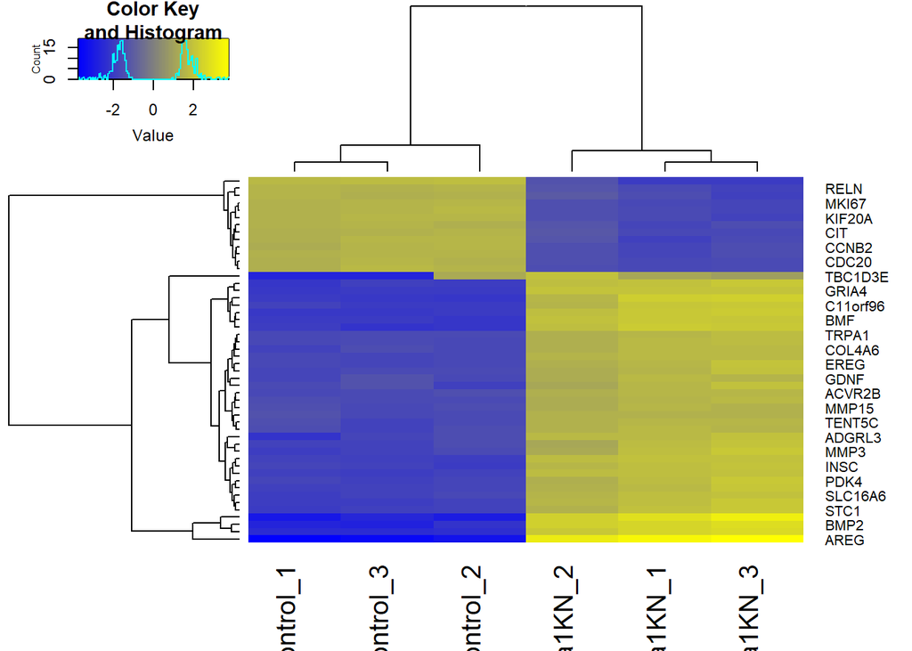

```r
# Add 1 to all CPM numbers and log2 transform the data
log_transformed_data <- log2(filtered_data + 1)

# Sort genes by standard deviations in descending order
gene_stddev <- apply(log_transformed_data, 1, sd)
log_transformed_data_sorted <- log_transformed_data[order(gene_stddev, decreasing = TRUE), ]

# Convert data to a matrix and update row names with gene symbols
log_transformed_data_matrix <- as.matrix(log_transformed_data_sorted)
rownames(log_transformed_data_matrix) <- gene_symbols[rownames(log_transformed_data_matrix)]

# Remove genes without gene symbols
log_transformed_data_matrix <- log_transformed_data_matrix[!is.na(rownames(log_transformed_data_matrix)), ]

# Subtract row means from all rows
centered_data <- sweep(log_transformed_data_matrix, 1, rowMeans(log_transformed_data_matrix))

# Plot heatmap of the top 50 genes
top50_genes <- centered_data[1:50, ]
heatmap.2(top50_genes, col = colorRampPalette(c("blue", "yellow"))(n = 100), trace = "none")
```

## Task 4

Continue analysis using the filtered and log-transformed data. Transpose the data frame and conduct PCA. Use ggplot2 to plot the samples by the first two components.

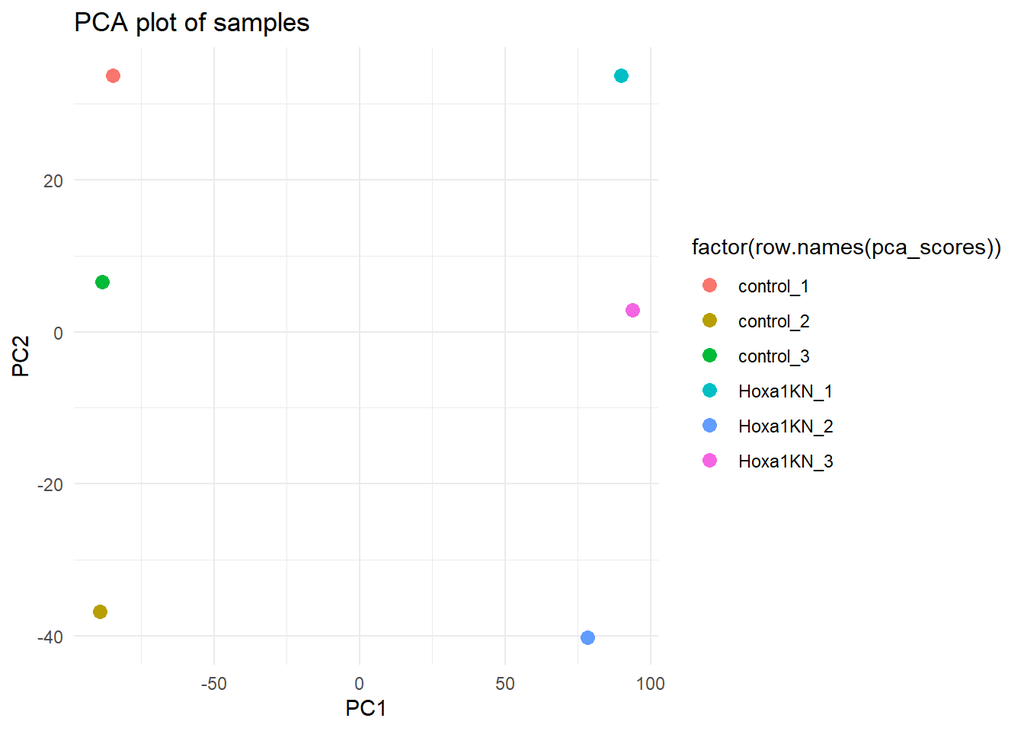

```r
# Load libraries
library(ggplot2)

# Transpose the data frame
transposed_data <- t(log_transformed_data)

# Perform PCA
pca_res <- prcomp(transposed_data, scale = TRUE, center = TRUE)

# Get the PCA scores
pca_scores <- as.data.frame(pca_res$x)

# Plot samples by the first two components using ggplot2
ggplot(pca_scores, aes(PC1, PC2)) +
  geom_point(size = 3, aes(color = factor(row.names(pca_scores)))) +
  labs(title = "PCA plot of samples", x = "PC1", y = "PC2") +
  theme_minimal()
```

## Task 5

From the raw count data, remove genes not included in the filtered CPM data. Use the resultant data to identify differentially expressed genes with the DESeq2 package. The first three columns are control samples. The last three are hoxa1 knockout. Remove genes with any missing values in the DESeq2 results. Generate a volcano plot, with lines at log fold change at 1 and FDR less than 0.01.

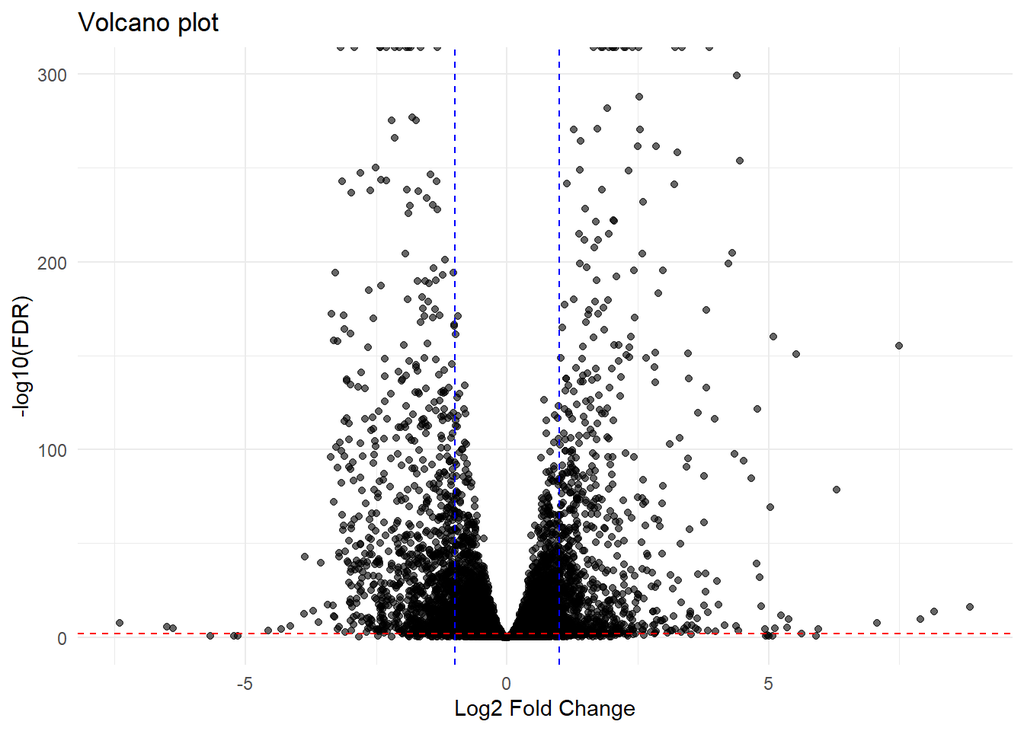

```r
# Load libraries
library(DESeq2)

# Remove unsupported genes from raw count data
filtered_raw_counts <- raw_counts[rownames(filtered_data),]

# Create a sample data frame for DESeq2 input
samples_info <- data.frame(
  condition = c(rep("control", 3), rep("hoxa1_knockout", 3)),
  row.names = colnames(filtered_raw_counts)
)

# Create DESeq2 object
dds <- DESeqDataSetFromMatrix(filtered_raw_counts, colData = samples_info, design = ~condition)

# Run DESeq2
res <- DESeq(dds)

# Get results and remove genes with any missing values
res_df <- results(res)
filtered_res_df <- res_df[complete.cases(res_df), ]

# Extract log2 fold change and padj from filtered results dataframe
log_fold_change <- filtered_res_df$log2FoldChange
padj <- filtered_res_df$padj

# Generate volcano plot
volcano_data <- data.frame(
  Log2FoldChange = log_fold_change,
  Padj = padj
)

ggplot(volcano_data, aes(Log2FoldChange, -log10(Padj))) +
  geom_point(alpha = 0.6) +
  geom_hline(yintercept = -log10(0.01), color = "red", linetype = "dashed") +
  geom_vline(xintercept = c(-1, 1), color = "blue", linetype = "dashed") +
  labs(
    title = "Volcano plot",
    x = "Log2 Fold Change",
    y = "-log10(FDR)"
  ) +
  theme_minimal()
```

## Task 6

Based on the DESeq2 result, identify up-regulated genes with FDR < 0.01 and LFC bigger than 1. Sort the genes by LFC in descending order. Using the gene information obtained above, create a data frame containing the following information for the up-regulated genes: log fold change, FDR, gene symbol, Ensembl IDs, Entrez IDs, and gene name.  
Save that into a CSV file. Print the top 10 genes.

```r
# Identify up-regulated genes with FDR < 0.01 and LFC > 1
upregulated_genes <- filtered_res_df[filtered_res_df$log2FoldChange > 1 & filtered_res_df$padj < 0.01, ]

# Sort the genes by LFC in descending order
upregulated_genes_sorted <- upregulated_genes[order(upregulated_genes$log2FoldChange, decreasing = TRUE), ]

# Create a data frame with the up-regulated gene information
upregulated_gene_info <- annotation_df[ensembl_ids %in% rownames(upregulated_genes_sorted), ]
upregulated_gene_info$LFC <- upregulated_genes_sorted$log2FoldChange
upregulated_gene_info$FDR <- upregulated_genes_sorted$padj

# Save the data frame to a CSV file
write.csv(upregulated_gene_info, "upregulated_genes.csv", row.names = FALSE)

# Print the top 10 genes
head(upregulated_gene_info, 10)
```

```
##                          GeneID  Symbol EntrezID
## ENSG00000185885 ENSG00000185885  IFITM1     8519
## ENSG00000173320 ENSG00000173320   STOX2    56977
## ENSG00000204385 ENSG00000204385 SLC44A4    80736
## ENSG00000009694 ENSG00000009694   TENM1    10178
## ENSG00000115919 ENSG00000115919    KYNU     8942
## ENSG00000141429 ENSG00000141429  GALNT1     2589
## ENSG00000095739 ENSG00000095739   BAMBI    25805
## ENSG00000175938 ENSG00000175938   ORAI3    93129
## ENSG00000129951 ENSG00000129951  PLPPR3    79948
## ENSG00000280447 ENSG00000280447    <NA>     <NA>
##                                                           GeneName      LFC
## ENSG00000185885         interferon induced transmembrane protein 1 8.852879
## ENSG00000173320                                    storkhead box 2 8.159839
## ENSG00000204385                  solute carrier family 44 member 4 7.901762
## ENSG00000009694                   teneurin transmembrane protein 1 7.501015
## ENSG00000115919                                       kynureninase 7.078835
## ENSG00000141429    polypeptide N-acetylgalactosaminyltransferase 1 6.306055
## ENSG00000095739           BMP and activin membrane bound inhibitor 5.956852
## ENSG00000175938 ORAI calcium release-activated calcium modulator 3 5.528578
## ENSG00000129951                 phospholipid phosphatase related 3 5.388239
## ENSG00000280447                                               <NA> 5.361719
##                           FDR
## ENSG00000185885  9.100289e-17
## ENSG00000173320  2.677477e-14
## ENSG00000204385  3.066683e-10
## ENSG00000009694 8.664006e-156
## ENSG00000115919  3.767997e-08
## ENSG00000141429  2.235549e-79
## ENSG00000095739  5.954466e-05
## ENSG00000175938 2.649798e-151
## ENSG00000129951  2.195809e-10
## ENSG00000280447  5.208091e-06
```

## Task 7

Conduct Gene Ontology enrichment analysis on the upregulated genes using the clusterProfiler package. Focus on GO Biological Process terms, excluding those with less than 5 or more than 5000 genes. Use the Entrez gene IDs in the last step and annotation in the org.Hs.eg.db package. Save the results to a CSV file. Use enrichplot to plot top 10 terms.

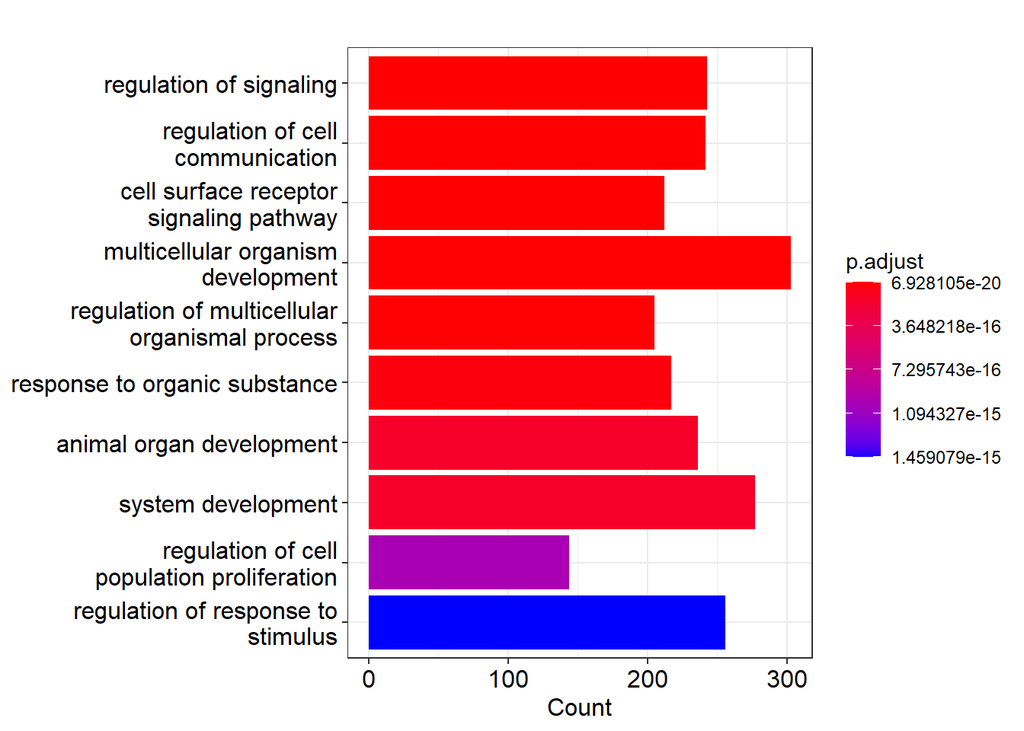

```r
# Load libraries
library(clusterProfiler)
library(enrichplot)

# Conduct GO enrichment analysis using filtered Entrez gene IDs
upregulated_entrez_ids <- upregulated_gene_info$EntrezID
org_hs_eg_go_bp <- enrichGO(upregulated_entrez_ids, OrgDb = org.Hs.eg.db,
                            ont = "BP", keyType = "ENTREZID",
                            pAdjustMethod = "BH", qvalueCutoff = 0.05,
                            minGSSize = 5, maxGSSize = 5000)

# Save the results to a CSV file
write.csv(org_hs_eg_go_bp@result, "GO_enrichment_results.csv", row.names = FALSE)

# Plot top 10 enriched terms
barplot(org_hs_eg_go_bp, showCategory = 10)
```

## Task 8

Repeat these analyses for down-regulated genes.

```r
# Identify down-regulated genes with FDR < 0.01 and LFC < -1
downregulated_genes <- filtered_res_df[filtered_res_df$log2FoldChange < -1 & filtered_res_df$padj < 0.01, ]

# Sort the genes by LFC (still negative LFC, so order should be increasing)
downregulated_genes_sorted <- downregulated_genes[order(downregulated_genes$log2FoldChange, decreasing = FALSE), ]

# Create a data frame with the down-regulated gene information
downregulated_gene_info <- annotation_df[ensembl_ids %in% rownames(downregulated_genes_sorted), ]
downregulated_gene_info$LFC <- downregulated_genes_sorted$log2FoldChange
downregulated_gene_info$FDR <- downregulated_genes_sorted$padj

# Save the data frame to a CSV file
write.csv(downregulated_gene_info, "downregulated_genes.csv", row.names = FALSE)

# Print the top 10 genes
head(downregulated_gene_info, 10)
```

```
##                          GeneID   Symbol EntrezID
## ENSG00000134057 ENSG00000134057    CCNB1      891
## ENSG00000197646 ENSG00000197646 PDCD1LG2    80380
## ENSG00000196639 ENSG00000196639     HRH1     3269
## ENSG00000273170 ENSG00000273170     <NA>     <NA>
## ENSG00000107566 ENSG00000107566   ERLIN1    10613
## ENSG00000101134 ENSG00000101134     DOK5    55816
## ENSG00000172716 ENSG00000172716   SLFN11    91607
## ENSG00000111348 ENSG00000111348  ARHGDIB      397
## ENSG00000189056 ENSG00000189056     RELN     5649
## ENSG00000221955 ENSG00000221955  SLC12A8    84561
##                                            GeneName       LFC          FDR
## ENSG00000134057                           cyclin B1 -7.398862 2.507822e-08
## ENSG00000197646    programmed cell death 1 ligand 2 -6.504120 4.099307e-06
## ENSG00000196639               histamine receptor H1 -6.379446 3.164220e-05
## ENSG00000273170                                <NA> -4.565766 3.679744e-04
## ENSG00000107566          ER lipid raft associated 1 -4.314880 5.848289e-05
## ENSG00000101134                   docking protein 5 -4.139267 8.134532e-07
## ENSG00000172716           schlafen family member 11 -3.877502 4.329155e-13
## ENSG00000111348 Rho GDP dissociation inhibitor beta -3.870996 1.900411e-43
## ENSG00000189056                              reelin -3.697769 1.005123e-14
## ENSG00000221955   solute carrier family 12 member 8 -3.597735 9.392102e-09
```

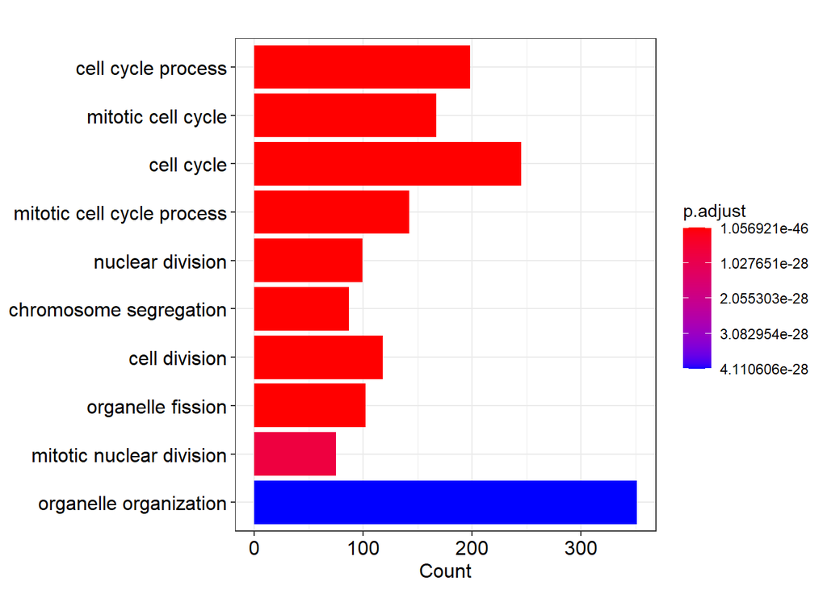

```r
# Conduct GO enrichment analysis using filtered Entrez gene IDs
downregulated_entrez_ids <- downregulated_gene_info$EntrezID
org_hs_eg_go_bp_2 <- enrichGO(downregulated_entrez_ids, OrgDb = org.Hs.eg.db,
                              ont = "BP", keyType = "ENTREZID",
                              pAdjustMethod = "BH", qvalueCutoff = 0.05,
                              minGSSize = 5, maxGSSize = 5000)

# Save the results to a CSV file
write.csv(org_hs_eg_go_bp_2@result, "GO_enrichment_results_downregulated.csv", row.names = FALSE)

# Plot top 10 enriched terms
barplot(org_hs_eg_go_bp_2, showCategory = 10)
```

## Task 9

Use the gage package to retrieve KEGG pathways for humans. Show the number of pathways. Show the name of the genes in the first pathway.

```r
# Load libraries
library(gage)
library(KEGGREST)

# Retrieve KEGG pathway gene sets for humans
kegg_pathways <- kegg.gsets(species = "hsa", id.type = "uniprot")
kegg_path_ids <- kegg_pathways$kg.sets

# Show the number of pathways
cat("Number of KEGG pathways for humans:", length(kegg_path_ids), "\n")
```

```
## Number of KEGG pathways for humans: 347
```

```r
# Show the name of the genes in the first pathway
first_pathway_genes <- kegg_path_ids[[1]]
cat("Name of the genes in the first pathway:", toString(first_pathway_genes), "\n")
```

```
## Name of the genes in the first pathway: 10327, 124, 125, 126, 127, 128, 130, 130589, 131, 160287, 1737, 1738, 2023, 2026, 2027, 217, 218, 219, 2203, 221, 222, 223, 224, 226, 229, 230, 2538, 2597, 26330, 2645, 2821, 3098, 3099, 3101, 387712, 3939, 3945, 3948, 441531, 501, 5105, 5106, 5160, 5161, 5…
```

## Task 10

Perform pathway analysis using the gage package and the KEGG pathways just retrieved. Use the filtered and log transformed data obtained above. Change the row names to Entrez gene IDs using the gene information retrieved. The first three samples are controls. The last three are mutant. Save the information for both up- and down-regulated pathways to files. Print the information for the top three top upregulated and down regulated pathways. Extract and show the pathway IDs of the three top upregulated pathways. The pathway IDs are the first word of the pathway name. More information about the parameters for the gage function: exprs:  
an expression matrix or matrix-like data structure, with genes as rows and samples as columns. gsets a named list, each element contains a gene set that is a character vector of gene IDs or symbols. For example, type head(kegg.gs). A gene set can also be a ‘smc’ object defined in PGSEA package. Please make sure that the same gene ID system is used for both gsets and exprs. ref: a numeric vector of column numbers for the reference condition or phenotype (i.e. the control group) in the exprs data matrix. Default ref = NULL, all columns are considered as target experiments. samp: a numeric vector of column numbers for the target condition or phenotype (i.e. the experiment group) in the exprs data matrix. Default samp = NULL, all columns other than ref are considered as target experiments. set.size: gene set size (number of genes) range to be considered for enrichment test. Tests for too small or too big gene sets are not robust statistically or informative biologically. Default to be set.size = c(10, 500). same.dir: boolean, whether to test for changes in a gene set toward a single direction (all genes up or down regulated) or changes towards both directions simultaneously. For experimentally derived gene sets, GO term groups, etc, coregulation is commonly the case, hence same.dir = TRUE (default); In KEGG, BioCarta pathways, genes frequently are not coregulated, hence it could be informative to let same.dir = FALSE. Although same.dir = TRUE could also be interesting for pathways.

```r
# Load libraries
library(gage)

# Change the row names to Entrez gene IDs
entrez_row_names <- as.character(annotation_df$EntrezID[match(rownames(log_transformed_data), annotation_df$GeneID)])
log_transformed_data_entrez <- log_transformed_data
rownames(log_transformed_data_entrez) <- entrez_row_names

# Perform pathway analysis
gage_res <- gage(exprs = log_transformed_data_entrez, gsets = kegg_path_ids,
                ref = 1:3, samp = 4:6, same.dir = TRUE)

# Get upregulated and downregulated pathways
upregulated_pathways <- gage_res$greater[, "q.val"] < 0.1
downregulated_pathways <- gage_res$less[, "q.val"] < 0.1

# Save pathway information to files
write.csv(gage_res$greater[upregulated_pathways, ], "upregulated_pathways.csv", row.names = TRUE)
write.csv(gage_res$less[downregulated_pathways, ], "downregulated_pathways.csv", row.names = TRUE)

# Print top three upregulated and downregulated pathways
cat("Top 3 upregulated pathways:\n")
```

```
## Top 3 upregulated pathways:
```

```r
print(head(gage_res$greater[upregulated_pathways, ], 3))
```

```
##                                                    p.geomean stat.mean
## hsa05168 Herpes simplex virus 1 infection       9.315815e-09  5.667182
## hsa04060 Cytokine-cytokine receptor interaction 1.916457e-05  4.210392
## hsa04142 Lysosome                               8.639240e-05  3.821728
##                                                        p.val        q.val
## hsa05168 Herpes simplex virus 1 infection       1.326215e-22 4.283673e-20
## hsa04060 Cytokine-cytokine receptor interaction 5.296440e-13 8.553751e-11
## hsa04142 Lysosome                               3.959899e-11 4.263491e-09
##                                                 set.size    Hoxa1KN_1
## hsa05168 Herpes simplex virus 1 infection            429 1.297660e-07
## hsa04060 Cytokine-cytokine receptor interaction      118 6.351525e-05
## hsa04142 Lysosome                                    115 4.466493e-05
##                                                    Hoxa1KN_2    Hoxa1KN_3
## hsa05168 Herpes simplex virus 1 infection       2.276315e-08 2.736966e-10
## hsa04060 Cytokine-cytokine receptor interaction 6.629705e-06 1.671572e-05
## hsa04142 Lysosome                               9.816339e-05 1.470653e-04
```

```r
cat("Top 3 downregulated pathways:\n")
```

```
## Top 3 downregulated pathways:
```

```r
print(head(gage_res$less[downregulated_pathways, ], 3))
```

```
##                                         p.geomean stat.mean        p.val
## hsa04110 Cell cycle                  4.926561e-08 -5.478360 1.409270e-20
## hsa03030 DNA replication             6.353072e-06 -4.710154 2.191872e-14
## hsa01230 Biosynthesis of amino acids 1.296416e-04 -3.773100 1.297723e-10
##                                             q.val set.size    Hoxa1KN_1
## hsa04110 Cell cycle                  4.551943e-18      150 7.134192e-08
## hsa03030 DNA replication             3.539873e-12       35 3.134401e-05
## hsa01230 Biosynthesis of amino acids 1.397215e-08       56 5.124829e-05
##                                         Hoxa1KN_2    Hoxa1KN_3
## hsa04110 Cell cycle                  1.369176e-07 1.224130e-08
## hsa03030 DNA replication             2.991589e-06 2.734605e-06
## hsa01230 Biosynthesis of amino acids 2.135687e-04 1.990749e-04
```

```r
# Extract pathway IDs of the three top upregulated pathways
top_up_pathway_ids <- sapply(stringr::str_split(rownames(head(gage_res$greater[upregulated_pathways, ], 3)), split = " "), function(x) x[1])
```

```
## Error in h(simpleError(msg, call)): error in evaluating the argument 'X' in selecting a method for function 'sapply': unused argument (split = " ")
```

```r
# Show the pathway IDs of the three top upregulated pathways
cat("Pathway IDs of the three top upregulated pathways:", toString(top_up_pathway_ids), "\n")
```

```
## Error in toString(top_up_pathway_ids): object 'top_up_pathway_ids' not found
```